# Suicide by Firearm

### Difference of suicide by age, sex, and education

```
There are 391743 deaths amoung those with some high school education or graduated, 47696 are female and 344047 are male. The average age in this population is 49.63.
There are 293480 deaths amoung those with some college education or graduated, 46673 are female and 246807 are male. The average age in this population is 50.98.
There are 9636 deaths among those with unknown levels of education, 1210 are female and 8426 are male. The average age in this population is 57.65.
```

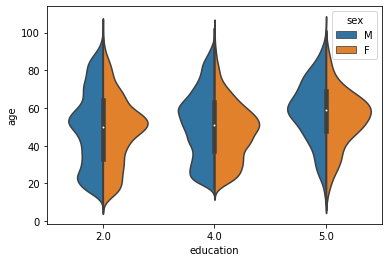

```python
newEdu = suicides['education'].replace(1,2).replace(3,4)
newSuicides = suicides.assign(education=newEdu)
graph_obj = sns.violinplot(x= 'education', y='age', data=newSuicides, hue='sex', split=True)
highschool =  pd.DataFrame(data = newSuicides[(newSuicides.education == 2)])
college =  pd.DataFrame(data = newSuicides[(newSuicides.education == 4)])
unknown =  pd.DataFrame(data = suicides[(newSuicides.education == 5)])

high = "There are {:d} deaths amoung those with some high school education or graduated, {:d} are female and {:d} are male. The average age in this population is {:.2f}.".format(highschool.size, (pd.DataFrame(data = highschool[(highschool.sex == 'F')])).size, (pd.DataFrame(data = highschool[(highschool.sex == 'M')])).size, highschool['age'].mean())
col = "There are {:d} deaths amoung those with some college education or graduated, {:d} are female and {:d} are male. The average age in this population is {:.2f}.".format(college.size, pd.DataFrame(data = college[(college.sex == 'F')]).size, pd.DataFrame(data = college[(college.sex == 'M')]).size, college['age'].mean())
un = "There are {:d} deaths among those with unknown levels of education, {:d} are female and {:d} are male. The average age in this population is {:.2f}.".format(unknown.size, pd.DataFrame(data = unknown[(unknown.sex == 'F')]).size, pd.DataFrame(data = unknown[(unknown.sex == 'M')]).size, unknown['age'].mean())
print(high)
print(col)
print(un)

graph_obj
```

This plot mostly shows that education does not change the overall median age of firearm suicide. The average age of suicide is larger in the unknown education group. While the known education groups stays relatively similar, as stated above.

2 -> some high school/graduate 4 -> some college/graduate 5 -> unknown

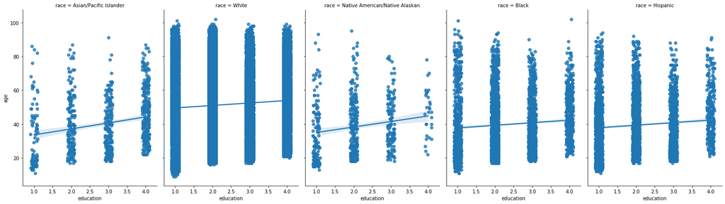

```python
newSuicide = pd.DataFrame(data=suicides[(suicides.education != 5)])
g = sns.lmplot(x = 'education', y = 'age', col='race', data=newSuicide,height=6,aspect=.7,x_jitter=.1)
g
```

```python
model = sm.ols('age~education*race', data=newSuicide).fit()
model.summary()
```

OLS Regression Results

| Dep. Variable: | age | R-squared: | 0.049 |
| --- | --- | --- | --- |
| Model: | OLS | Adj. R-squared: | 0.048 |
| Method: | Least Squares | F-statistic: | 353.0 |
| Date: | Mon, 18 May 2020 | Prob (F-statistic): | 0.00 |
| Time: | 21:57:58 | Log-Likelihood: | -2.7097e+05 |
| No. Observations: | 62291 | AIC: | 5.420e+05 |
| Df Residuals: | 62281 | BIC: | 5.421e+05 |
| Df Model: | 9 |  |  |
| Covariance Type: | nonrobust |  |  |

|  | coef | std err | t | P>\|t\| | [0.025 | 0.975] |
| --- | --- | --- | --- | --- | --- | --- |
| Intercept | 30.0438 | 2.087 | 14.396 | 0.000 | 25.953 | 34.134 |
| race[T.Black] | 6.1355 | 2.271 | 2.702 | 0.007 | 1.685 | 10.586 |
| race[T.Hispanic] | 6.2347 | 2.243 | 2.780 | 0.005 | 1.839 | 10.631 |
| race[T.Native American/Native Alaskan] | 1.7127 | 3.029 | 0.565 | 0.572 | -4.225 | 7.650 |
| race[T.White] | 18.0190 | 2.099 | 8.584 | 0.000 | 13.905 | 22.133 |
| education | 3.5421 | 0.684 | 5.180 | 0.000 | 2.202 | 4.882 |
| education:race[T.Black] | -2.0097 | 0.773 | -2.598 | 0.009 | -3.526 | -0.494 |
| education:race[T.Hispanic] | -2.0243 | 0.770 | -2.631 | 0.009 | -3.533 | -0.516 |
| education:race[T.Native American/Native Alaskan] | -0.2911 | 1.179 | -0.247 | 0.805 | -2.602 | 2.020 |
| education:race[T.White] | -2.0785 | 0.689 | -3.017 | 0.003 | -3.429 | -0.728 |

| Omnibus: | 3317.099 | Durbin-Watson: | 1.957 |
| --- | --- | --- | --- |
| Prob(Omnibus): | 0.000 | Jarque-Bera (JB): | 1405.035 |
| Skew: | 0.126 | Prob(JB): | 7.95e-306 |
| Kurtosis: | 2.309 | Cond. No. | 255. |

Warnings:  
[1] Standard Errors assume that the covariance matrix of the errors is correctly specified.

Further breaking down the education data by race, and running a regression on that data, it is shown that while it is true across all races that average age does increase with an increased level of education, the difference is minimal in White, Black, and Hispanic communities. The difference is more pronounced, however amongst Asian/Pacific Islanders and Native American and Native Alsaskan people. The results of this regression mostly show that education level may have some affect, but overall does not cause any significant change to the average age of suicide by firearm; this finding upholds the conclusion made from analysis of the above violin plots.

## Additional Resources:

From the CDC website stated below, this plotting of data supports our findings from the data covering 2012-2014. Much like the violin graph that focuses on suicide age by gender, this chart shows both male and female gun suicide peaking at around age 50, with males showing a spike around their 20s. One thing that is made abundantly clear here is that while male and female firearm suicide follows overall similar trends across different ages, the raw numbers have male suicide by firearm to be much greater than female suicide by firearm.

[figure not shown]

Source: (CDC WISQARS)

This data also should be viewed and understood under the important cultural backdrop of the amount of governmental funding and resource allocation to the issue of gun deaths in the United States. A 1996 provision to the federal government omnibus spending bill, known as the Dickey Amendment, mandates that "none of the funds made available for injury prevention and control at the Centers for Disease Control and Prevention (CDC) may be used to advocate or promote gun control." As stated by the New York Times, this amendment “stripped $2.6 million from the Centers for Disease Control and Prevention — the precise amount budgeted for a study of the health effects of shootings.” This legislation, put forth almost 25 years ago is still in effect today. This political landscape upon which strong research, analysis, and data depends, is critical to know and understand, and the reasons are twofold. 1. An organization like the CDC is heavily reliant on federal funding, and with no funding, the ability to put forth large, sweeping conclusions needed to help enact legal change are missing 2. Since the funding to research and analyze something is so pertinent to a highly prevalent modern health crisis, it is that much more important to analyze and pay attention to how different factors are at play within the data.

Sources:

https://www.nytimes.com/2017/04/24/us/jay-dickey-dead-arkansas-congressman.html?searchResultPosition=1

https://www.smithsonianmag.com/smart-news/cdc-still-cant-study-causes-gun-violence-180955884/?no-ist